# Predict examination score of students

Supervised learning with `final_test` as labels.

To predict examination score is a regression problems.

The analysis is done to determine the preprocessing necessary for features to feed into learning algorithms.

```python
import src.my_std_lib
import numpy as np
import pandas as pd
import matplotlib.pyplot as plt
import seaborn as sns
import joblib
print("libraries imported")
```

```
libraries imported
```

```python
# Read from the stored dataframe

pickle_name = 'data/' + 'score.pkl'
raw = joblib.load(pickle_name)
```

```python
raw.info()
```

```
<class 'pandas.core.frame.DataFrame'>
RangeIndex: 15900 entries, 0 to 15899
Data columns (total 18 columns):
 #   Column              Non-Null Count  Dtype
---  ------              --------------  -----
 0   index               15900 non-null  int64
 1   number_of_siblings  15900 non-null  int64
 2   direct_admission    15900 non-null  object
 3   CCA                 15900 non-null  object
 4   learning_style      15900 non-null  object
 5   student_id          15900 non-null  object
 6   gender              15900 non-null  object
 7   tuition             15900 non-null  object
 8   final_test          15405 non-null  float64
 9   n_male              15900 non-null  float64
 10  n_female            15900 non-null  float64
 11  age                 15900 non-null  float64
 12  hours_per_week      15900 non-null  float64
 13  attendance_rate     15122 non-null  float64
 14  sleep_time          15900 non-null  object
 15  wake_time           15900 non-null  object
 16  mode_of_transport   15900 non-null  object
 17  bag_color           15900 non-null  object
dtypes: float64(6), int64(2), object(10)
memory usage: 2.2+ MB
```

# Columns that have null values:

- final_test, which is also the label
- attendance_rate

```python
# What the data is like

raw.head(5)
```

|  | index | number_of_siblings | direct_admission | CCA | learning_style | student_id | gender | tuition | final_test | n_male | n_female | age | hours_per_week | attendance_rate | sleep_time | wake_time | mode_of_transport | bag_color |
| --- | --- | --- | --- | --- | --- | --- | --- | --- | --- | --- | --- | --- | --- | --- | --- | --- | --- | --- |
| 0 | 0 | 0 | Yes | Sports | Visual | ACN2BE | Female | No | 69.0 | 14.0 | 2.0 | 16.0 | 10.0 | 91.0 | 22:00 | 6:00 | private transport | yellow |
| 1 | 1 | 2 | No | Sports | Auditory | FGXIIZ | Female | No | 47.0 | 4.0 | 19.0 | 16.0 | 7.0 | 94.0 | 22:30 | 6:30 | private transport | green |
| 2 | 2 | 0 | Yes | None | Visual | B9AI9F | Male | No | 85.0 | 14.0 | 2.0 | 15.0 | 8.0 | 92.0 | 22:30 | 6:30 | private transport | white |
| 3 | 3 | 1 | No | Clubs | Auditory | FEVM1T | Female | Yes | 64.0 | 2.0 | 20.0 | 15.0 | 18.0 | NaN | 21:00 | 5:00 | public transport | yellow |
| 4 | 4 | 0 | No | Sports | Auditory | AXZN2E | Male | No | 66.0 | 24.0 | 3.0 | 16.0 | 7.0 | 95.0 | 21:30 | 5:30 | public transport | yellow |

```python
raw.tail(5)
```

|  | index | number_of_siblings | direct_admission | CCA | learning_style | student_id | gender | tuition | final_test | n_male | n_female | age | hours_per_week | attendance_rate | sleep_time | wake_time | mode_of_transport | bag_color |
| --- | --- | --- | --- | --- | --- | --- | --- | --- | --- | --- | --- | --- | --- | --- | --- | --- | --- | --- |
| 15895 | 15895 | 1 | No | Clubs | Visual | XPECN2 | Female | No | 56.0 | 12.0 | 14.0 | 16.0 | 9.0 | 96.0 | 22:00 | 6:00 | private transport | black |
| 15896 | 15896 | 1 | Yes | None | Auditory | 7AMC7S | Male | Yes | 85.0 | 17.0 | 5.0 | 16.0 | 7.0 | 91.0 | 22:30 | 6:30 | private transport | white |
| 15897 | 15897 | 1 | Yes | Sports | Auditory | XKZ6VN | Female | Yes | 76.0 | 7.0 | 10.0 | 15.0 | 7.0 | 93.0 | 23:00 | 7:00 | walk | red |
| 15898 | 15898 | 1 | No | Clubs | Visual | 2OU4UQ | Male | Yes | 45.0 | 18.0 | 12.0 | 16.0 | 3.0 | 94.0 | 23:00 | 7:00 | walk | yellow |
| 15899 | 15899 | 2 | Yes | None | Visual | D9OKLV | Male | No | 87.0 | 11.0 | 7.0 | 16.0 | 9.0 | 91.0 | 23:00 | 7:00 | walk | yellow |

# Sleep duration with `sleep_time` and `wake_time`

Sufficient sleep is important for health and exam. So, sleep duration is calculated from the sleep_time and wake_time.

```python
# Cast the sleep_time and wake_time to date time
format = '%H:%M'
raw['sleep_time'] = pd.to_datetime(raw['sleep_time'], format=format)
raw['sleep_time'].head(5)
```

```
0   1900-01-01 22:00:00
1   1900-01-01 22:30:00
2   1900-01-01 22:30:00
3   1900-01-01 21:00:00
4   1900-01-01 21:30:00
Name: sleep_time, dtype: datetime64[ns]
```

```python
raw['wake_time'] = pd.to_datetime(raw['wake_time'], format=format)
raw['wake_time'].head(5)
```

```
0   1900-01-01 06:00:00
1   1900-01-01 06:30:00
2   1900-01-01 06:30:00
3   1900-01-01 05:00:00
4   1900-01-01 05:30:00
Name: wake_time, dtype: datetime64[ns]
```

```python
# Find the hour of sleep
diff_time = pd.to_timedelta(raw['wake_time']-raw['sleep_time'], unit='h')
diff_time
```

```
0       -1 days +08:00:00
1       -1 days +08:00:00
2       -1 days +08:00:00
3       -1 days +08:00:00
4       -1 days +08:00:00
               ...
15895   -1 days +08:00:00
15896   -1 days +08:00:00
15897   -1 days +08:00:00
15898   -1 days +08:00:00
15899   -1 days +08:00:00
Length: 15900, dtype: timedelta64[ns]
```

```python
# Timedelta in seconds of the total
# sleeping hours.
diff_time.dt.seconds
```

```
0        28800
1        28800
2        28800
3        28800
4        28800
         ...
15895    28800
15896    28800
15897    28800
15898    28800
15899    28800
Length: 15900, dtype: int32
```

```python
# Convert timedelta seconds to hours
# 1 hour = 3600s
diff_time.dt.seconds / 3600
```

```
0        8.0
1        8.0
2        8.0
3        8.0
4        8.0
        ...
15895    8.0
15896    8.0
15897    8.0
15898    8.0
15899    8.0
Length: 15900, dtype: float64
```

```python
# Add sleep hours to the data

raw['sleep_duration'] =  diff_time.dt.seconds / 3600
```

```python
cols = ['sleep_time', 'wake_time', 'sleep_duration']
raw[cols]
```

|  | sleep_time | wake_time | sleep_duration |
| --- | --- | --- | --- |
| 0 | 1900-01-01 22:00:00 | 1900-01-01 06:00:00 | 8.0 |
| 1 | 1900-01-01 22:30:00 | 1900-01-01 06:30:00 | 8.0 |
| 2 | 1900-01-01 22:30:00 | 1900-01-01 06:30:00 | 8.0 |
| 3 | 1900-01-01 21:00:00 | 1900-01-01 05:00:00 | 8.0 |
| 4 | 1900-01-01 21:30:00 | 1900-01-01 05:30:00 | 8.0 |
| ... | ... | ... | ... |
| 15895 | 1900-01-01 22:00:00 | 1900-01-01 06:00:00 | 8.0 |
| 15896 | 1900-01-01 22:30:00 | 1900-01-01 06:30:00 | 8.0 |
| 15897 | 1900-01-01 23:00:00 | 1900-01-01 07:00:00 | 8.0 |
| 15898 | 1900-01-01 23:00:00 | 1900-01-01 07:00:00 | 8.0 |
| 15899 | 1900-01-01 23:00:00 | 1900-01-01 07:00:00 | 8.0 |

15900 rows × 3 columns

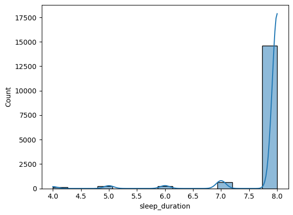

```python
# Distribution of sleep duration
sns.histplot(raw, x='sleep_duration', kde=True)
```

```python
# Summary of sleep hour
raw['sleep_duration'].describe().T
```

```
count    15900.000000
mean         7.846478
std          0.602334
min          4.000000
25%          8.000000
50%          8.000000
75%          8.000000
max          8.000000
Name: sleep_duration, dtype: float64
```

### Sleep duration

Sleep duration is almost a binary value. 0.25 to 1 quartiles are 8.0. It can be binarized during preprocessing.

# sleep_duration, hours_per_week, attendance_rate and final_test

Relationship between these variables.

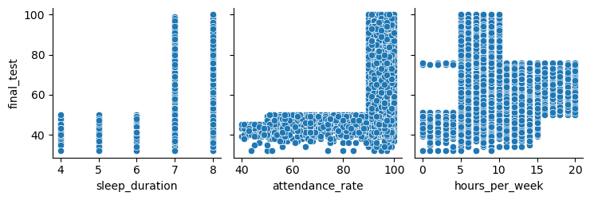

```python
# Pairplots to see the relationship

def plot_sleep_attn_revision():
    sns.pairplot(data=raw,
                  x_vars=['sleep_duration', 'attendance_rate', 'hours_per_week'],
                  y_vars=['final_test'])

plot_sleep_attn_revision()
```

### Summary

Both higher sleep_duration and attendance relates to higher final_test score.

Revision hours_per_week from 5 to 10 hours relates to higher final_test score.

```python
# Make the sleep_duration clearly by indicating enough or lacking

raw['sleep_enough'] = pd.cut(raw['sleep_duration'], bins=[0, 7, 9], labels=['sleep_lacking', 'sleep_enough'], retbins=False)
raw['sleep_enough'].tail(5)
```

```
15895    sleep_enough
15896    sleep_enough
15897    sleep_enough
15898    sleep_enough
15899    sleep_enough
Name: sleep_enough, dtype: category
Categories (2, object): ['sleep_lacking' < 'sleep_enough']
```

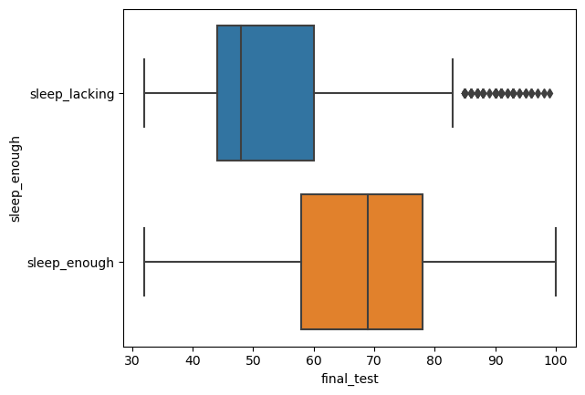

```python
# sleep_enough and final_test

sns.boxplot(data=raw, x='final_test', y='sleep_enough')
```

The groups with enough sleep or not have very distinct mean and interquartile range of `final_test`. It will be useful in prediction.

# `attendance_rate`

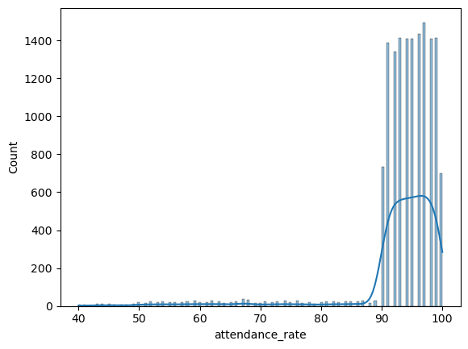

```python
# Distribution of attendance_rate.
# Check this before imputing null values
# in attendace rate.
sns.histplot(data=raw, x='attendance_rate', kde=True)
```

### `attendance_rate` is binary class like

There are just two levels or binary class for `attendance_rate`. To make this features more efficient, it can be binarized. During preprocessing `attendance_rate` can be binarize.

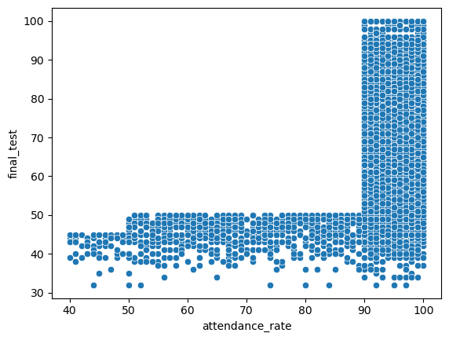

```python
# attendance_rate and final_test

sns.scatterplot(data=raw, x='attendance_rate', y='final_test')
```

### Relationship between attendance_rate and final_test

- The attendance_rate below about the 90% is made up of score of about 50 and below.
- Even with attendance_rate of 90% and above, there are also scores below 50.

```python
raw['attendance_rate'].describe().T
```

```
count    15122.000000
mean        93.270268
std          7.984230
min         40.000000
25%         92.000000
50%         95.000000
75%         97.000000
max        100.000000
Name: attendance_rate, dtype: float64
```

```python
raw['attendance_rate'].isna().any()
```

```
True
```

```python
# histogram distribution plot and the describe summary
# shows that 25 percentile to 75% of attendance_rate
# is from 92% to 97%.
# It is quite safe to impute the null values to median.

# The distribution is highly skew. Almost uniformly
# distributed around 92% to 97%.
med = raw['attendance_rate'].agg(np.median)
med
```

```
95.0
```

```python
# Fill in the null values
raw['attendance_rate'] = raw['attendance_rate'].fillna(value=med)
```

```python
# Confirm that there is no more null values
raw['attendance_rate'].isna().any()
```

```
False
```

```python
raw['attendance_rate'].describe().T
```

```
count    15900.000000
mean        93.354906
std          7.795366
min         40.000000
25%         92.000000
50%         95.000000
75%         97.000000
max        100.000000
Name: attendance_rate, dtype: float64
```

After imputing `attendance_rate`,

- Change of mean: from 93.27 to 93.35
- Change of std: from 7.98 to 7.80

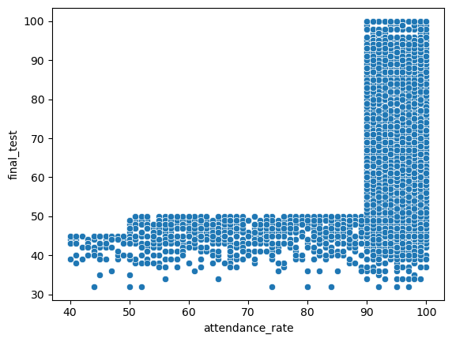

```python
# After imputing
sns.scatterplot(data=raw, x='attendance_rate', y='final_test')
```

After imputing, the distribution of attendance_rate and final_test stays the same.

```python
# Binarize the attendance_rate

q1 = raw['attendance_rate'].quantile(0.25)
raw['attendance_enough'] = pd.cut(raw['attendance_rate'],
                    bins=[0, q1, 100.0],
                    labels=['lacking', 'enough']
                    )
raw['attendance_enough'].tail()
```

```
15895     enough
15896    lacking
15897     enough
15898     enough
15899    lacking
Name: attendance_enough, dtype: category
Categories (2, object): ['lacking' < 'enough']
```

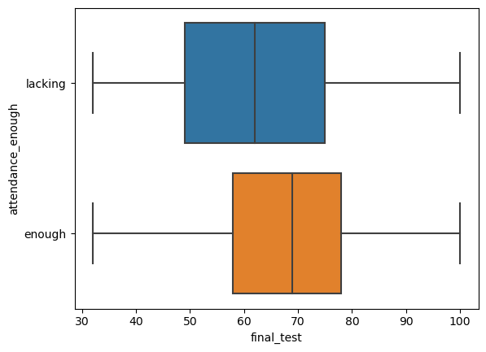

```python
# attendance_enough and final_test
sns.boxplot(data=raw, x='final_test', y='attendance_enough')
```

# `final_test` label

A total of 495 (495/15900=3.11%) is missing. Since this is the label used for learning. Imputing this label with values like mean or median can affect the learning.

It is best to drop the samples with missing values.

```python
# Number of missing values

num_missing = raw['final_test'].isna().sum()
print(f"Number of missing final_test: {num_missing}")
```

```
Number of missing final_test: 495
```

```python
pc_missing = num_missing / len(raw) * 100
print(f"Percentage of missing values {pc_missing:.4f}")
```

```
Percentage of missing values 3.1132
```

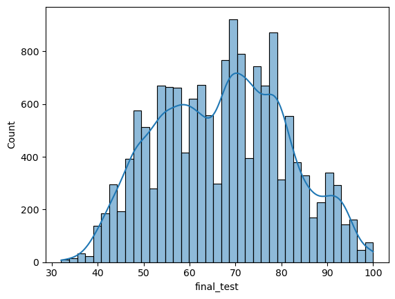

```python
# Check the distribution
sns.histplot(data=raw, x='final_test', kde=True)
```

```python
raw['final_test'].agg(['mean', 'median'])
```

```
mean      67.165401
median    68.000000
Name: final_test, dtype: float64
```

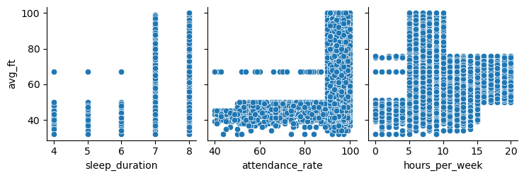

```python
# The distribution is about symmetric, centering
# around the mean.

# Try impute the null values in final test with
# mean.
mean_final = raw['final_test'].agg(np.mean)
raw['avg_ft'] = raw['final_test'].fillna(value=mean_final)

# Check the pairplot after imputation
sns.pairplot(data=raw,
             x_vars=['sleep_duration', 'attendance_rate', 'hours_per_week'],
             y_vars=['avg_ft']
            )
```

After experimenting with imputing the `final_test` with mean, the relationship with other variables changes. Notice the horizontal line at the mean values at about 68. This line does not appear in the pairplot before this.

This appear to introduce unwanted noise in the label `final_test`, so, the null values will be dropped instead.

```python
# Drop rows when `final_test` is null

raw.dropna(subset=['final_test'], how='any', inplace=True)
```

```python
# Is there still any null values?
# Confirm that there is no more null values.
raw['final_test'].isnull().any()
```

```
False
```

```python
raw['final_test'].describe().T
```

```
count    15405.000000
mean        67.165401
std         13.977879
min         32.000000
25%         56.000000
50%         68.000000
75%         78.000000
max        100.000000
Name: final_test, dtype: float64
```

The `final_test` has a std of about 14.00. This is noted. When the regression performance is evaluated. The std should not too worse than this 'labelled' std.

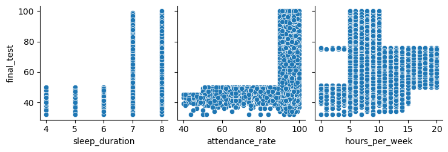

```python
# Check the pairplot after dropping the null values
sns.pairplot(data=raw,
             x_vars=['sleep_duration', 'attendance_rate', 'hours_per_week'],
             y_vars=['final_test']
            )
```

The dropping of missing values in `final_test` does not affect the other variables.

### Changes to `final_test` after dropping sample rows

- Changes to mean:The mean stays at 67.17

# `direct_admission`

```python
# How direct admission affect the final test

adm_count = raw['direct_admission'].value_counts()
adm_count
```

```
direct_admission
No                  10857
Yes                  4548
Name: count, dtype: int64
```

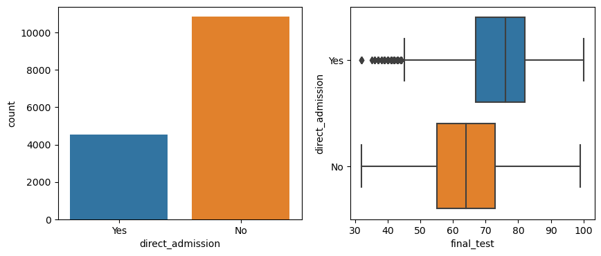

```python
fig, axes = plt.subplots(nrows=1, ncols=2, figsize=(10, 4))

sns.countplot(data=raw, x='direct_admission', ax=axes[0])

sns.boxplot(data=raw, x='final_test', y='direct_admission', ax=axes[1])
```

#### Distribution of score for direct_admission and final_test

For direct_admission='yes',

- The boxplot shows that there are many outliers below the 25% quartile.
- Its 25% to 75% quantile is clearly higher than the direct_admission='no'.

For direct_admission='no',

- the distribution looks more evenly distributed around the mean.
- there are no outliers.

# `hours_per_week`

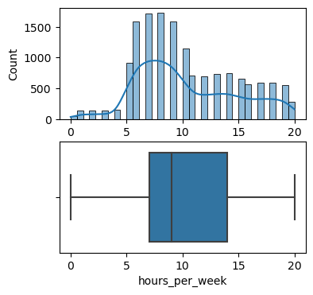

```python
# Distribution of hours_per_week
fig, axes = plt.subplots(nrows=2, ncols=1, figsize=(4, 4))
sns.histplot(raw, x='hours_per_week', kde=True, ax=axes[0])
sns.boxplot(raw, x='hours_per_week', ax=axes[1])
```

```python
raw['hours_per_week'].describe()
```

```
count    15405.000000
mean        10.312301
std          4.463029
min          0.000000
25%          7.000000
50%          9.000000
75%         14.000000
max         20.000000
Name: hours_per_week, dtype: float64
```

The mean 10.31 is more than the median 9.00. The distribution is positively skewed and pulled towards the right by the max 20. The right tail is fat because of the higher frequency of greater value of `hours_per_week`.

This feature will be left as it is. In its plain, unscaled form, it can be used by decision tree-based algorithms. It will be standard scaled when used by algorithms like linear model, knn or svm.

# `gender`

```python
# Gender
# Almost about the same number of male and female
raw['gender'].value_counts()
```

```
gender
Male      7744
Female    7661
Name: count, dtype: int64
```

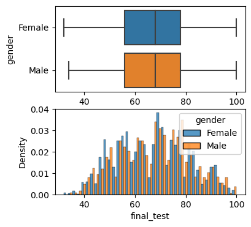

```python
fig, axes = plt.subplots(nrows=2, ncols=1, figsize=(4,4))
sns.boxplot(data=raw, x='final_test', y='gender', ax=axes[0])
sns.histplot(data=raw, x="final_test", hue="gender", multiple='dodge', stat="density", common_norm=False, ax=axes[1])
```

```python
# Summary of the final_test grouped by gender
raw.groupby(by='gender')['final_test'].describe()
```

| gender | count | mean | std | min | 25% | 50% | 75% | max |
| --- | --- | --- | --- | --- | --- | --- | --- | --- |
| Female | 7661.0 | 66.999869 | 14.045027 | 32.0 | 56.0 | 68.0 | 78.0 | 100.0 |
| Male | 7744.0 | 67.329158 | 13.910100 | 34.0 | 56.0 | 68.0 | 78.0 | 100.0 |

The boxplot and the descriptive statistics summary show that the distribution of females and males in the final_test is the about the same. There is no difference between male and female in final_test.

This feature will not be considered for prediction.

# `n_female` and `n_male`

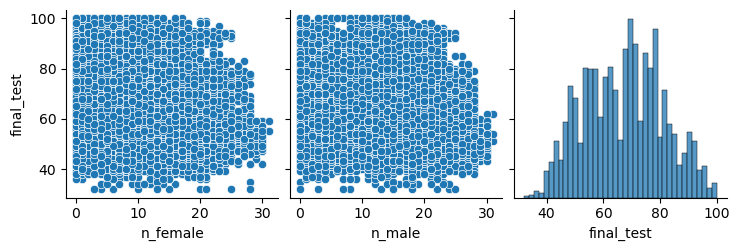

```python
sns.pairplot(data=raw,
             x_vars=['n_female', 'n_male', 'final_test'],
             y_vars=['final_test']
    )
```

`n_female` and `n_male` will not be considered for predictions.

# `CCA`

```python
# What are the unique values of CCA?
raw['CCA'].unique()
```

```
array(['Sports', 'None', 'Clubs', 'Arts', 'ARTS', 'SPORTS', 'CLUBS',
       'NONE'], dtype=object)
```

```python
# make the category name all lowercase
raw['CCA'] = raw['CCA'].apply(str.lower)
```

```python
# Now, it is easier to see the category in CCA
raw['CCA'].unique()
```

```
array(['sports', 'none', 'clubs', 'arts'], dtype=object)
```

```python
raw.groupby('CCA')['final_test'].describe()
```

| CCA | count | mean | std | min | 25% | 50% | 75% | max |
| --- | --- | --- | --- | --- | --- | --- | --- | --- |
| arts | 3791.0 | 64.061989 | 13.158185 | 32.0 | 54.0 | 63.0 | 74.0 | 100.0 |
| clubs | 3940.0 | 63.850761 | 12.972272 | 32.0 | 54.0 | 63.0 | 74.0 | 100.0 |
| none | 3831.0 | 76.778648 | 12.153547 | 32.0 | 68.0 | 78.0 | 86.0 | 100.0 |
| sports | 3843.0 | 64.041894 | 13.042459 | 32.0 | 54.0 | 64.0 | 74.0 | 100.0 |

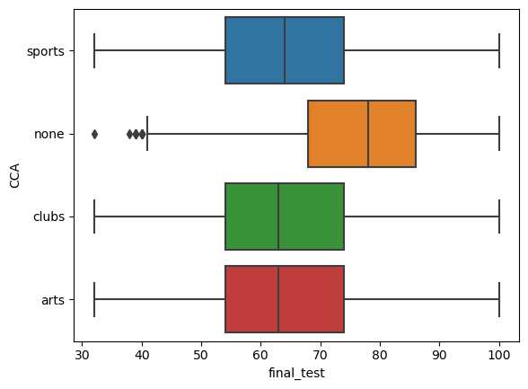

```python
# Check how different category of CCA affect final_test

sns.boxplot(data=raw, x='final_test', y='CCA')
```

The `None` CCA has a higher mean 77 `final_test` than the other three categories of CCA.

The other three categories have about the same mean 64. They belong to one class.

This `CCA` feature will be made into two classes:

- `None` as one category,
- `arts`, `sports`, `clubs` as one category.

```python
#The categories in `cca` is `some` or `none` to indicate whether there is CCA or not.

def replace_category(s, new_name, old_name_list):
    if s in old_name_list:
        s = s.replace(s, new_name)
    return s

raw['cca'] = raw['CCA'].apply(lambda s: replace_category(s, 'some', ['arts', 'sports','clubs']))
raw['cca'].unique()
```

```
array(['some', 'none'], dtype=object)
```

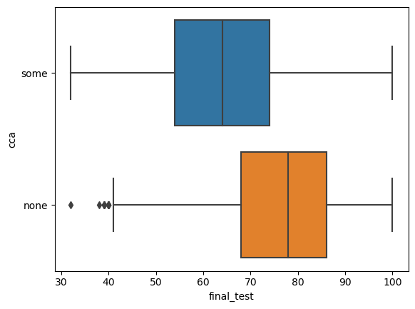

```python
# Check the CCA after group the categories together

sns.boxplot(data=raw, x='final_test', y='cca')
```

The `cca=none` has higher mean of `final_test` than the `cca=some`. It is affecting `final_test`.

# `tuition`

```python
# Check the values in tuition
raw['tuition'].unique()
```

```
array(['No', 'Yes', 'Y', 'N'], dtype=object)
```

```python
# Make the unique values into only 'yes', 'no'
# Make the category values lowercase
def replace_tuition(s):
    if s in ['Yes', 'Y']:
        s = s.replace(s, 'yes')
    if s in ['No', 'N']:
        s = s.replace(s, 'no')
    return s

raw['tuition'] = raw['tuition'].apply(replace_tuition)
raw['tuition'].unique()
```

```
array(['no', 'yes'], dtype=object)
```

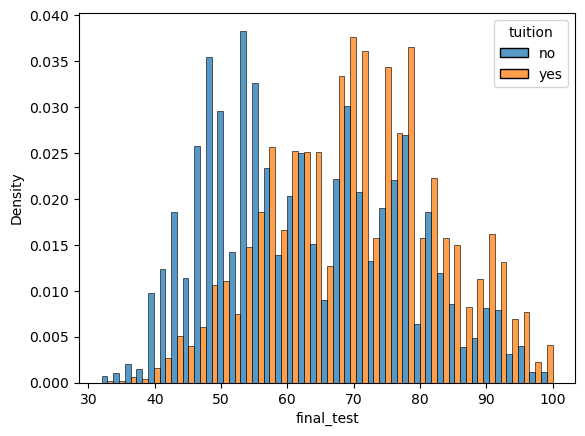

```python
sns.histplot(data=raw, x='final_test', hue='tuition', multiple='dodge', stat='density', common_norm=False)
```

Group with tuition=yes has higher final_test values than the group with tuition=no.

The distribution in the center is about the same.

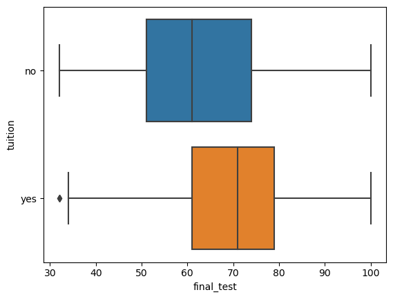

```python
# Check the box plot of tuition against final_test

sns.boxplot(data=raw, x='final_test', y='tuition')
```

The group with tuition=yes has a narrower interquartile range. But it has an outlier at the low final_test value.

```python
# Statistics summary

raw.groupby(by='tuition')['final_test'].describe()
```

| tuition | count | mean | std | min | 25% | 50% | 75% | max |
| --- | --- | --- | --- | --- | --- | --- | --- | --- |
| no | 6689.0 | 62.864404 | 14.225541 | 32.0 | 51.0 | 61.0 | 74.0 | 100.0 |
| yes | 8716.0 | 70.466154 | 12.843240 | 32.0 | 61.0 | 71.0 | 79.0 | 100.0 |

The std of `tuition=no` is larger 14.22, and IQR is from 51.0 to 74.0, therefore larger spread of final_test values.

The std of `tuition=yes` is smaller 12.84, and IQR is from 61.0 to 79.0, therefore narrower spread compared to `tuition=no`.

This `tuition` will be turned into binary values during preprocessing.

# `learning_style`

```python
# Check the values
raw['learning_style'].unique()
```

```
array(['Visual', 'Auditory'], dtype=object)
```

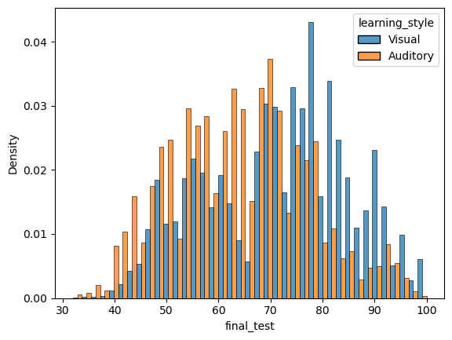

```python
# Check the distribution
sns.histplot(data=raw, x='final_test', hue='learning_style', multiple='dodge', stat='density', common_norm=False)
```

For final_test above 70%, group with `Visual` is the dominant group.

For final_test below 70%, group with `Auditory` is the dominant group.

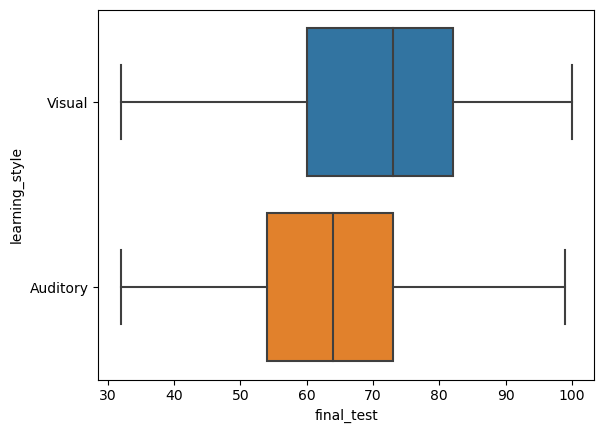

```python
# Check the boxplot
sns.boxplot(data=raw, x='final_test', y='learning_style')
```

The `Visual` group has higher mean but also larger interquartile range.

The `Auditory` group has lower mean but narrower interquartile range.

```python
# Stats summary
raw.groupby('learning_style')['final_test'].describe()
```

| learning_style | count | mean | std | min | 25% | 50% | 75% | max |
| --- | --- | --- | --- | --- | --- | --- | --- | --- |
| Auditory | 8847.0 | 63.888324 | 13.114772 | 32.0 | 54.0 | 64.0 | 73.0 | 99.0 |
| Visual | 6558.0 | 71.586307 | 13.889588 | 32.0 | 60.0 | 73.0 | 82.0 | 100.0 |

The summary of statistics shows that the mean of `Auditory` style is 63.89 lower than the `Visual` 71.59.

It is affecting the `final_test` and will be used for prediction.

The `learning_style` will be made into a binary class during preprocessing.

# `number_of_siblings`

```python
# What are the values
raw['number_of_siblings'].unique()
```

```
array([0, 2, 1], dtype=int64)
```

```python
raw['number_of_siblings'].value_counts()
```

```
number_of_siblings
1    6494
0    5326
2    3585
Name: count, dtype: int64
```

Most students has 1 sibling. The number of students with 2 siblings is the fewest.

```python
# Need to change the number 0, 1, 2 to strings in order to use
# boxplot.
def replace_num(s):
    if s == 0:
        return 'none'
    elif s == 1:
        return 'one'
    elif s == 2:
        return 'two'

raw['number_of_siblings'] = raw['number_of_siblings'].apply(replace_num)
raw['number_of_siblings'].unique()
```

```
array(['none', 'two', 'one'], dtype=object)
```

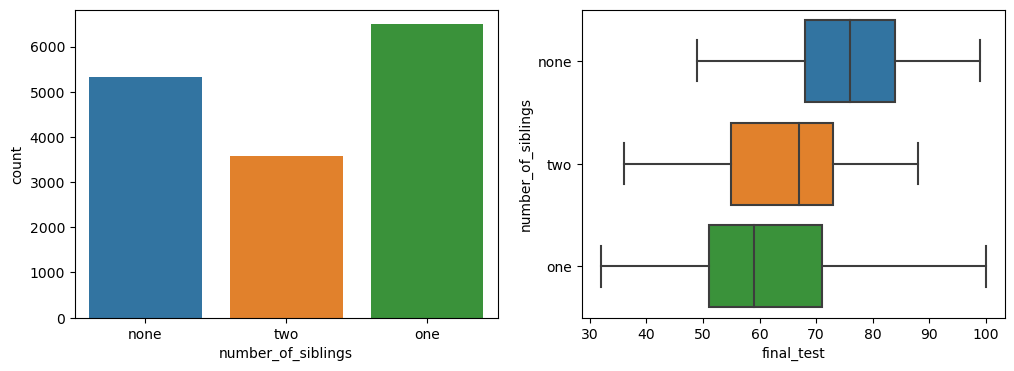

```python
fig, axes = plt.subplots(nrows=1, ncols=2, figsize=(12, 4))
# Count of siblings
sns.countplot(data=raw, x='number_of_siblings', ax=axes[0])
# With three categories, using boxplot will be easier
# to see the differences among the categories.
sns.boxplot(data=raw, x='final_test', y='number_of_siblings', ax=axes[1])
```

```python
# Stats summary

raw.groupby(by='number_of_siblings')['final_test'].describe()
```

| number_of_siblings | count | mean | std | min | 25% | 50% | 75% | max |
| --- | --- | --- | --- | --- | --- | --- | --- | --- |
| none | 5326.0 | 75.974277 | 10.971114 | 49.0 | 68.0 | 76.0 | 84.0 | 99.0 |
| one | 6494.0 | 61.787958 | 13.562872 | 32.0 | 51.0 | 59.0 | 71.0 | 100.0 |
| two | 3585.0 | 63.819526 | 12.196199 | 36.0 | 55.0 | 67.0 | 73.0 | 88.0 |

Students with no sibling has higher overall final_test score. Its mean and min is the highest compared to those with one or two siblings. Its IQR is the narrowest from 84-68=16. Its min-max is 99-49=50.

The different mean and min-max is affecting the final_test score.

# `mode_of_transport`

```python
# Check the values of mode_of_transport
raw['mode_of_transport'].unique()
```

```
array(['private transport', 'public transport', 'walk'], dtype=object)
```

```python
# Change the category values to shorter names
def replace_transport(s):
    if s == 'private transport':
        return 'private'
    elif s == 'public transport':
        return 'public'
    return s # unchanged for walk

# rename the mode_of_transport to a shorter name
raw.rename(columns={'mode_of_transport':'transport'}, inplace=True)
raw['transport'] = raw['transport'].apply(replace_transport)
raw['transport'].unique()
```

```
array(['private', 'public', 'walk'], dtype=object)
```

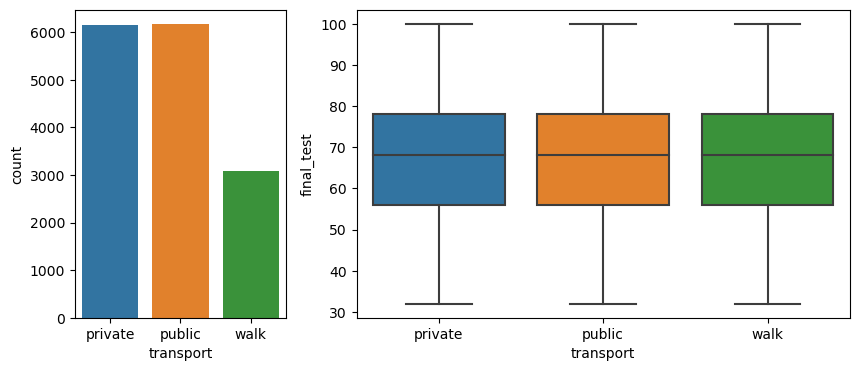

```python
fig, axes = plt.subplots(nrows=1, ncols=2, figsize=(10, 4), width_ratios=[0.3, 0.7])

sns.countplot(data=raw, x='transport', ax=axes[0])
sns.boxplot(data=raw, x='transport', y='final_test', ax=axes[1])
```

```python
# Stat summary
raw.groupby(by='transport')['final_test'].describe()
```

| transport | count | mean | std | min | 25% | 50% | 75% | max |
| --- | --- | --- | --- | --- | --- | --- | --- | --- |
| private | 6146.0 | 67.253010 | 14.018165 | 32.0 | 56.0 | 68.0 | 78.0 | 100.0 |
| public | 6165.0 | 67.099108 | 13.926842 | 32.0 | 56.0 | 68.0 | 78.0 | 100.0 |
| walk | 3094.0 | 67.123465 | 14.002827 | 32.0 | 56.0 | 68.0 | 78.0 | 100.0 |

The are about equal number of students taking private and public transport. About 1/5 proportion of the students walk.

The students taking different transport have the same mean and spread of final_test from the box plot.

The stats show a neglible differences between mean and std. The IQR and min-max are the same for all three modes of transport.

So, there is no influences of mode_of_transport on the `final_test`. This feature will not be considered during learning.

# `age`

```python
# Check values of age
raw['age'].unique()
```

```
array([16., 15.,  5.,  6., -4., -5.])
```

The age -5, -4, 5 and 6 appears to be mistakes in the input. The majority of values is 15 and 16. Therefore, it is quite safe to assume that the -5 and 5 are actually 15, and -4 and 6 are actually 16.

```python
# Correct the values
# Change the value to category for comparison
def correct_age(a):
    if (a == -5) or (a == 5) or (a==15):
        a = 'fifteen'
    elif (a == -4) or (a == 6) or (a==16):
        a = 'sixteen'
    return a

raw['age'] = raw['age'].apply(correct_age)
raw['age'].unique()
```

```
array(['sixteen', 'fifteen'], dtype=object)
```

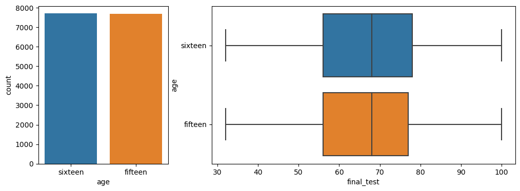

```python
# What is the distribution of age?
# Make the chart smaller
fig, axes = plt.subplots(nrows=1, ncols=2 , figsize=(12,4), width_ratios=[0.3, 0.7])
sns.countplot(data=raw, x='age', ax=axes[0])
sns.boxplot(data=raw, x='final_test', y='age', ax=axes[1])
```

```python
# Stat summary
raw.groupby(by='age')['final_test'].describe()
```

| age | count | mean | std | min | 25% | 50% | 75% | max |
| --- | --- | --- | --- | --- | --- | --- | --- | --- |
| fifteen | 7693.0 | 67.097881 | 13.837569 | 32.0 | 56.0 | 68.0 | 77.0 | 100.0 |
| sixteen | 7712.0 | 67.232754 | 14.117029 | 32.0 | 56.0 | 68.0 | 78.0 | 100.0 |

There are about equal number of students from age 15 or 16.

The boxplot shows that there is not much different between students of age 15 or 16.

The differences in age group and final_test is not significant. `age` will not be included in learning.

# `bag_color` and `student_id`

Both of these variables would not influence `final_test`. These features would not be used during processing.